# End Year Report

Loong Kuan

13 January 2017

# Aim

Previously, the project was only able to analyse the changes between 2 given sets of data. However, this requires the user to know and split their dataset at the point where drift occurs beforehand.

Therefore, during the trip I worked towards adding functionality in order to show any occurences of concept drift in an entire data set or stream.

# Outline of Work Done

The first thing I realised was that the old model I used, `FrequencyTable`, was inadequate for calculating the drift magnitude over an entire data set or stream in a timeley manner. Therefore, I created a new model, `FrequencyMaps`, which through experimentation, seems to be faster at just calculating the drift magnitude over an entire data set/stream.

With a faster model, I then developed a simple method to analyse the drift magnitude over an entire data set. Testing this method on synthetic data showed that it was sufficient to obtain an estimate of where abrupt concept drift occurs in a data set.

With a new method to estimate where drift occurs in a data set, I went back and analysed the concept drift in data sets that, previously, I had only analysed through splitting the data set in half.

# New Model for streaming data (FrequencyMaps)

## FrequqencyTable (recap)

Previously, the project used a `FrequencyTable` to store the frequencies at which different instances appear in the given dataset.

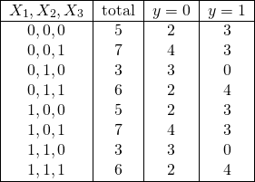

Figure 1: `FrequencyTable`

The `FrequencyTable` allows for new instances to be added in linear time to the number of attributes in the data set. Furthermore, the frequency of partial instances of different attribute subset lengths can be queried from the same `FrequencyTable`.

However, in order to obtain the frequency of a single partial instance from a `FrequencyTable`, we need to either iterate through each row of the table or all the possible values of the attributes not given a value in the partial instance. This time complexity is amplified further by the fact there is a combinatorial number of attribute subsets for a given attribute subset length with each attribute subset having an exponential number of partial instances.

In order to reduce time taken to obtain all the frequencies, I created a new model that trades Space Complexity for Time. Specifically, it increases space complexity by an combinatorial factor to reduce final time complexity by an exponential factor.

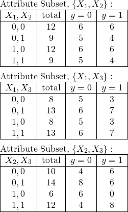

Figure 2: `FrequencyMap`

The model works by storing the `FrequencyTables` of each possible attribute subset of a given attribute subset length. So, given a partial instance to find the frequency of, the model will first look at the attributes in the partial instace that are given values. Based on that, it will access the appropiate `FrequencyTable` and find the frequency of the partial instance by hashing the partial instance.

Therefore, not only is this model limited to obtaining the frequencies of a fixed attribute subset length, but it has a greater time complexity for adding instances and greater space complexity.

## Comparison

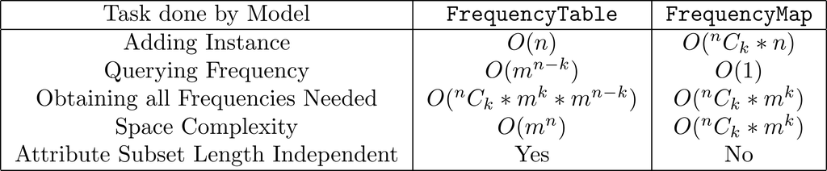

Figure 3: Comparison between `FrequencyTable` and `FrequencyMap`